# Yiddish VO/OV

MK

27 November, 2026

## Setup

```r
library(ggplot2)
library(dplyr)
library(tidyr)
library(lme4) # probably a bit too optimistic with the amount of data we have!
```

## Background

I ran coding queries on PPCHY and our finished files, looking for pronominal/nominal object / reflexive / RP / RP-H preceding and following non-finite verbs in IP-MAT, IP-SUB, IP-INF and IP-PPL.

I have excluded cases where the element of interest precedes a finite auxiliary, as I’m assuming that these would not be informative.

### Summary of Variables

The messy version

[output not shown]

## Prepare Data

Load data, add variable names:

```r
d1 <- read.delim("marjuqueries.ppchy.nodates.cod.ooo", header=F, sep=":")
d2 <- read.delim("marjuqueries.ourcorpus.nodates.cod.ooo", header=F, sep=":")

d <- rbind(d1, d2)
colnames(d) <- c("ClauseType", "WordOrder", "Element", "Modality", "Year", "Corpus", "Text", "Token")
head(d)
```

```
##   ClauseType WordOrder Element Modality Year Corpus                        Text
## 1          z         z pronobj  written 1478  ppchy 1478w-letter-regensburg,156
## 2          z         z pronobj  written 1478  ppchy 1478w-letter-regensburg,156
## 3          z         z       z  written 1478  ppchy 1478w-letter-regensburg,156
## 4          z         z       z  written 1478  ppchy 1478w-letter-regensburg,156
## 5        sub        ov      rp  written 1478  ppchy 1478w-letter-regensburg,156
## 6          z         z  posobj  written 1478  ppchy 1478w-letter-regensburg,156
##   Token
## 1     3
## 2     4
## 3     5
## 4     6
## 5     6
## 6     7
```

```r
nrow(d)
```

```
## [1] 37204
```

Remove irrelevant instances with `z`:

```r
data <- subset(d, ClauseType != "z" & WordOrder != "z" & Element != "z")

nrow(data)
```

```
## [1] 9085
```

Turn strings to factors, check:

```r
data <- mutate_if(data, is.character, as.factor)
data$Year <- as.numeric(as.character(data$Year))
summary(data)
```

```
##  ClauseType     WordOrder             Element        Modality         Year
##  inf:1150   ov       :5806   posobj       :2824   spoken :1041   Min.   :1413
##  mat:5746   ovo      : 879   pronobj      :1667   written:8044   1st Qu.:1750
##  ppl:  96   ovo_check:  28   rp           :1314                  Median :1926
##  sub:2093   vo       :2372   rfl          : 936                  Mean   :1851
##                              qobj         : 560                  3rd Qu.:1947
##                              rp_and_posobj: 543                  Max.   :2000
##                              (Other)      :1241                  NAs    :20
##        Corpus
##  ourcorpus:2294
##  ppchy    :6791
##
##
##
##
##
##                                                        Text
##  1996e-dimantstein.int.yid,                              : 468
##  1925e-bastomski.nar-folk.yid,                           : 229
##  2000eh-kraut.int.yid,                                   : 222
##  1916e-aleykhem-bandiii-nybc202585_0012_0039.nar-fic.yid,: 210
##  1947e-royte-pomerantsen,248                             : 167
##  1995e-abramson.int.yid,                                 : 161
##  (Other)                                                 :7628
##      Token
##  Min.   :   2.00
##  1st Qu.:  88.75
##  Median : 262.50
##  Mean   :1109.38
##  3rd Qu.:1030.25
##  Max.   :6697.00
##  NAs    :13
```

Remove NAs (Some tokens without labels?)

```r
data <- na.omit(data)
summary(data)
```

```
##  ClauseType     WordOrder             Element        Modality         Year
##  inf:1148   ov       :5791   posobj       :2817   spoken :1041   Min.   :1413
##  mat:5731   ovo      : 878   pronobj      :1660   written:8023   1st Qu.:1750
##  ppl:  96   ovo_check:  28   rp           :1310                  Median :1926
##  sub:2089   vo       :2367   rfl          : 935                  Mean   :1851
##                              qobj         : 560                  3rd Qu.:1947
##                              rp_and_posobj: 543                  Max.   :2000
##                              (Other)      :1239
##        Corpus
##  ourcorpus:2274
##  ppchy    :6790
##
##
##
##
##
##                                                        Text          Token
##  1996e-dimantstein.int.yid,                              : 468   Min.   :   2
##  1925e-bastomski.nar-folk.yid,                           : 229   1st Qu.:  89
##  2000eh-kraut.int.yid,                                   : 222   Median : 263
##  1916e-aleykhem-bandiii-nybc202585_0012_0039.nar-fic.yid,: 210   Mean   :1110
##  1947e-royte-pomerantsen,248                             : 167   3rd Qu.:1032
##  1995e-abramson.int.yid,                                 : 161   Max.   :6697
##  (Other)                                                 :7607
```

Check for dating errors (when token number is listed as the year instead of actual year).

```r
data %>% filter (Year == Token)
```

```
## [1] ClauseType WordOrder  Element    Modality   Year       Corpus     Text
## [8] Token
## <0 rows> (or 0-length row.names)
```

Reorder some labels for convenience

```r
data$WordOrder <- factor(data$WordOrder, levels = c("vo", "ov", "ovo", "ovo_check"))

data$ClauseType <- factor(data$ClauseType,
                          levels = c("mat", "sub", "inf", "ppl"))
```

Combine IP-INF with IP-PPL and IP-MAT with IP-SUB for later plotting purposes

```r
data <- data %>%
  mutate(Finiteness = ifelse(
    ClauseType %in% c("ppl", "inf"),
    "NonFinite",
    "Finite"
  ))
```

### Messy-messy!

The number of postverbal thingies in the different clause types:

```r
freq <- table(data$ClauseType, data$WordOrder)
freq
```

```
##
##         vo   ov  ovo ovo_check
##   mat 1359 3761  588        23
##   sub  519 1400  166         4
##   inf  462  569  116         1
##   ppl   27   61    8         0
```

And percentages for each clause type:

```r
round(prop.table(freq, margin = 1) * 100, 3)
```

```
##
##           vo     ov    ovo ovo_check
##   mat 23.713 65.626 10.260     0.401
##   sub 24.844 67.018  7.946     0.191
##   inf 40.244 49.564 10.105     0.087
##   ppl 28.125 63.542  8.333     0.000
```

And a look at the different elements:

```r
table(data$ClauseType, data$WordOrder, data$Element)
```

```
## , ,  = posobj
##
##
##         vo   ov  ovo ovo_check
##   mat 1137  433   15        16
##   sub  445  211    1         3
##   inf  389  147    0         1
##   ppl   17    2    0         0
##
## , ,  = pronobj
##
##
##         vo   ov  ovo ovo_check
##   mat   15 1168    0         0
##   sub    3  368    0         0
##   inf   17   87    0         0
##   ppl    1    1    0         0
##
## , ,  = pronobj_and_posobj
##
##
##         vo   ov  ovo ovo_check
##   mat    2   57  167         0
##   sub    1   17   43         0
##   inf    6    7   10         0
##   ppl    1    1    0         0
##
## , ,  = pronobj_and_qobj
##
##
##         vo   ov  ovo ovo_check
##   mat    1   29   42         0
##   sub    0    9    9         0
##   inf    0    2    1         0
##   ppl    0    0    0         0
##
## , ,  = qobj
##
##
##         vo   ov  ovo ovo_check
```

[output cut: 70 more lines]

```
##
##         vo   ov  ovo ovo_check
##   mat    1   23   48         3
##   sub    2   15    9         0
##   inf    1    5    5         0
##   ppl    0    0    1         0
##
## , ,  = rp_and_rfl
##
##
##         vo   ov  ovo ovo_check
##   mat    0  193   18         0
##   sub    0   65    4         0
##   inf    0   28   10         0
##   ppl    0    0    0         0
```

#### Looking at the messy codes

Straightforward recoding:

- `ovo` for `posobj` is not behaving well and is picking up stuff where one of the nominal objects is before the finite verb. Recode these as `vo`. `ovo_check` ones would be true OVO for these, so I’ll have to exclude them for now…
- `ovo` for `pronobj_and_posobj` means `ov` for `pronobj` and `vo` for `posobj`. Could double count these for the purposes of plotting to have more data in each category; likewise for `pronobj_and_qobj`
- `ovo` for `rfl_and_posobj` have `ov` for `rfl` and `vo` for `posobj`; likewise for `rfl_and_qobj`
- `rp_and_posobj` `ovo` are `ov` for `rp` and `vo` for `posobj`, vice versa for `ovo_check`; Same for `rp_and_qobj`.

Coding query things to worry about another time:

- `ovo` for `rp`, `rfl`, `rp_and_pronobj` and `rp_and_rfl` are a mess because they include cases with regular objects postverbally. Oops! Will need to fix the queries. For now, just exclude these hoping that I’m not generating a confound.
- just a couple of OVO ones for `qobj` - who knows what is happening here. Get rid. Maybe investigate later why these have different labels (these are from ourcorpus)
- currently no `posobj_and_qobj` label; worry about this later (if at all)

#### Let’s add some element-based variables to avoid duplicating the data

```r
data <- data %>%
  mutate(RP = case_when(
   Element == "rp" & WordOrder == "vo" ~ "VO",
   Element == "rp" & WordOrder == "ov" ~ "OV",
   Element == "rp_and_posobj" & WordOrder == "ovo" ~ "OV",
   Element == "rp_and_posobj" & WordOrder == "ovo_check" ~ "VO",
   Element == "rp_and_posobj" & WordOrder == "ov" ~ "OV",
   Element == "rp_and_posobj" & WordOrder == "vo" ~ "VO",
   Element == "rp_and_qobj" & WordOrder == "ovo" ~ "OV",
   Element == "rp_and_qobj" & WordOrder == "ovo_check" ~ "VO",
   Element == "rp_and_qobj" & WordOrder == "ov" ~ "OV",
   Element == "rp_and_qobj" & WordOrder == "vo" ~ "VO",
   Element == "rp_and_pronobj" & WordOrder == "ov" ~ "OV",
   Element == "rp_and_pronobj" & WordOrder == "vo" ~ "VO",
   Element == "rp_and_rfl" & WordOrder == "ov" ~ "OV",
   Element == "rp_and_rfl" & WordOrder == "vo" ~ "VO", # that should cover the RPs and exclude messy cases
  TRUE ~ NA_character_
  ),
  RFL = case_when(
   Element == "rfl" & WordOrder == "vo" ~ "VO",
   Element == "rfl" & WordOrder == "ov" ~ "OV",
   Element == "rfl_and_posobj" & WordOrder == "ovo" ~ "OV",
   Element == "rfl_and_posobj" & WordOrder == "ovo_check" ~ "VO",
   Element == "rfl_and_posobj" & WordOrder == "ov" ~ "OV",
   Element == "rfl_and_posobj" & WordOrder == "vo" ~ "VO",
   Element == "rfl_and_qobj" & WordOrder == "ovo" ~ "OV",
   Element == "rfl_and_qobj" & WordOrder == "ovo_check" ~ "VO",
   Element == "rfl_and_qobj" & WordOrder == "ov" ~ "OV",
   Element == "rfl_and_qobj" & WordOrder == "vo" ~ "VO",
   Element == "rfl_and_pronobj" & WordOrder == "ov" ~ "OV",
   Element == "rfl_and_pronobj" & WordOrder == "vo" ~ "VO",
   Element == "rp_and_rfl" & WordOrder == "ov" ~ "OV",
   Element == "rp_and_rfl" & WordOrder == "vo" ~ "VO", # that should cover the RFLs and exclude messy cases
  TRUE ~ NA_character_
  ),
   PRONOBJ = case_when(
   Element == "pronobj" & WordOrder == "vo" ~ "VO",
   Element == "pronobj" & WordOrder == "ov" ~ "OV",
   Element == "pronobj_and_posobj" & WordOrder == "ovo" ~ "OV",
   Element == "pronobj_and_posobj" & WordOrder == "ovo_check" ~ "VO",
   Element == "pronobj_and_posobj" & WordOrder == "ov" ~ "OV",
   Element == "pronobj_and_posobj" & WordOrder == "vo" ~ "VO",
   Element == "pronobj_and_qobj" & WordOrder == "ovo" ~ "OV",
   Element == "pronobj_and_qobj" & WordOrder == "ovo_check" ~ "VO",
   Element == "pronobj_and_qobj" & WordOrder == "ov" ~ "OV",
   Element == "pronobj_and_qobj" & WordOrder == "vo" ~ "VO",
   Element == "rfl_and_pronobj" & WordOrder == "ov" ~ "OV",
   Element == "rfl_and_pronobj" & WordOrder == "vo" ~ "VO",
   Element == "rp_and_pronobj" & WordOrder == "ov" ~ "OV",
   Element == "rp_and_pronobj" & WordOrder == "vo" ~ "VO", # that should cover the PRONOBJ
  TRUE ~ NA_character_
  ),
   POSOBJ = case_when(
   Element == "posobj" & WordOrder == "vo" ~ "VO",
   Element == "posobj" & WordOrder == "ov" ~ "OV",
   Element == "posobj" & WordOrder == "ovo" ~ "VO",
   Element == "pronobj_and_posobj" & WordOrder == "ovo" ~ "VO",
   Element == "pronobj_and_posobj" & WordOrder == "ovo_check" ~ "OV",
   Element == "pronobj_and_posobj" & WordOrder == "ov" ~ "OV",
   Element == "pronobj_and_posobj" & WordOrder == "vo" ~ "VO",
   Element == "rfl_and_posobj" & WordOrder == "ovo" ~ "VO",
   Element == "rfl_and_posobj" & WordOrder == "ovo_check" ~ "OV",
   Element == "rfl_and_posobj" & WordOrder == "ov" ~ "OV",
   Element == "rfl_and_posobj" & WordOrder == "vo" ~ "VO",
   Element == "rp_and_posobj" & WordOrder == "ovo" ~ "VO",
   Element == "rp_and_posobj" & WordOrder == "ovo_check" ~ "OV",
   Element == "rp_and_posobj" & WordOrder == "ov" ~ "OV",
   Element == "rp_and_posobj" & WordOrder == "vo" ~ "VO",    # that should cover the POSOBJ, since no query combined with qobj
  TRUE ~ NA_character_
  ),
     QOBJ = case_when(
   Element == "qobj" & WordOrder == "vo" ~ "VO",
   Element == "qobj" & WordOrder == "ov" ~ "OV",
   Element == "pronobj_and_qobj" & WordOrder == "ovo" ~ "VO",
   Element == "pronobj_and_qobj" & WordOrder == "ovo_check" ~ "OV",
   Element == "pronobj_and_qobj" & WordOrder == "ov" ~ "OV",
   Element == "pronobj_and_qobj" & WordOrder == "vo" ~ "VO",
   Element == "rfl_and_qobj" & WordOrder == "ovo" ~ "VO",
   Element == "rfl_and_qobj" & WordOrder == "ovo_check" ~ "OV",
   Element == "rfl_and_qobj" & WordOrder == "ov" ~ "OV",
   Element == "rfl_and_qobj" & WordOrder == "vo" ~ "VO",
   Element == "rp_and_qobj" & WordOrder == "ovo" ~ "VO",
   Element == "rp_and_qobj" & WordOrder == "ovo_check" ~ "OV",
   Element == "rp_and_qobj" & WordOrder == "ov" ~ "OV",
   Element == "rp_and_qobj" & WordOrder == "vo" ~ "VO",    # that should cover the QOBJ
  TRUE ~ NA_character_
  ) ) %>%
  mutate_if(is.character, as.factor)

summary(data)
```

```
##  ClauseType     WordOrder             Element        Modality         Year
##  mat:5731   vo       :2367   posobj       :2817   spoken :1041   Min.   :1413
##  sub:2089   ov       :5791   pronobj      :1660   written:8023   1st Qu.:1750
##  inf:1148   ovo      : 878   rp           :1310                  Median :1926
##  ppl:  96   ovo_check:  28   rfl          : 935                  Mean   :1851
##                              qobj         : 560                  3rd Qu.:1947
##                              rp_and_posobj: 543                  Max.   :2000
##                              (Other)      :1239
##        Corpus
##  ourcorpus:2274
##  ppchy    :6790
##
##
##
##
##
##                                                        Text          Token
##  1996e-dimantstein.int.yid,                              : 468   Min.   :   2
##  1925e-bastomski.nar-folk.yid,                           : 229   1st Qu.:  89
##  2000eh-kraut.int.yid,                                   : 222   Median : 263
##  1916e-aleykhem-bandiii-nybc202585_0012_0039.nar-fic.yid,: 210   Mean   :1110
##  1947e-royte-pomerantsen,248                             : 167   3rd Qu.:1032
##  1995e-abramson.int.yid,                                 : 161   Max.   :6697
##  (Other)                                                 :7607
##      Finiteness     RP        RFL       PRONOBJ    POSOBJ      QOBJ
##  Finite   :7820   OV :2502   OV :1244   OV :2320   OV :1031   OV : 364
##  NonFinite:1244   VO :  21   VO :  37   VO :  47   VO :2661   VO : 402
##                   NAs:6541   NAs:7783   NAs:6697   NAs:5372   NAs:8298
##
##
##
##
```

## Exploring the Data

### Cleaner tables

Let’s get the percent of postverbal occurrences for each element, in each clause type. This will include clauses that have multiple such elements, and I’m just treating things on an individual basis here. There are some exclusions as discussed in the messy bits above, some of which can be fixed by more thoughtful querying in the future

#### All data

```r
data %>%
  pivot_longer(
    cols = c(RP, RFL, PRONOBJ, POSOBJ, QOBJ),
    names_to = "Constituent",
    values_to = "Order"
  ) %>%
  group_by(ClauseType, Constituent) %>%
  summarise(
    n_VO = sum(Order == "VO", na.rm = TRUE),
    n_OV = sum(Order == "OV", na.rm = TRUE),
    prop_VO = mean(Order == "VO", na.rm = TRUE) * 100,
    result = sprintf("%.2f%% (%d/%d)",
                     prop_VO, n_VO, n_VO + n_OV),
    .groups = "drop"
  ) %>%
  select(ClauseType, Constituent, result) %>%
  pivot_wider(
    names_from = Constituent,
    values_from = result
  ) %>%
  select(ClauseType, RP, PRONOBJ, RFL, POSOBJ, QOBJ)  %>%
  knitr::kable(
    caption = "Proportion of VO order by IP type and constituent (all data)"
  )
```

Proportion of VO order by IP type and constituent (all data)

| ClauseType | RP | PRONOBJ | RFL | POSOBJ | QOBJ |
| --- | --- | --- | --- | --- | --- |
| mat | 0.74% (11/1493) | 1.06% (18/1703) | 0.99% (9/911) | 73.09% (1570/2148) | 55.06% (283/514) |
| sub | 0.80% (5/626) | 0.78% (4/511) | 0.75% (2/265) | 67.61% (576/852) | 46.67% (84/180) |
| inf | 1.46% (5/342) | 15.44% (23/149) | 21.21% (21/99) | 73.80% (490/664) | 46.97% (31/66) |
| ppl | 0.00% (0/62) | 50.00% (2/4) | 83.33% (5/6) | 89.29% (25/28) | 66.67% (4/6) |

#### PPCHY

```r
data %>%
  filter(Corpus == "ppchy") %>%
  pivot_longer(
    cols = c(RP, RFL, PRONOBJ, POSOBJ, QOBJ),
    names_to = "Constituent",
    values_to = "Order"
  ) %>%
  group_by(ClauseType, Constituent) %>%
  summarise(
    n_VO = sum(Order == "VO", na.rm = TRUE),
    n_OV = sum(Order == "OV", na.rm = TRUE),
    prop_VO = mean(Order == "VO", na.rm = TRUE) * 100,
    result = sprintf("%.2f%% (%d/%d)",
                     prop_VO, n_VO, n_VO + n_OV),
    .groups = "drop"
  ) %>%
  select(ClauseType, Constituent, result) %>%
  pivot_wider(
    names_from = Constituent,
    values_from = result
  ) %>%
  select(ClauseType, RP, PRONOBJ, RFL, POSOBJ, QOBJ)  %>%
  knitr::kable(
    caption = "Proportion of VO order by IP type and constituent (PPCHY)"
  )
```

Proportion of VO order by IP type and constituent (PPCHY)

| ClauseType | RP | PRONOBJ | RFL | POSOBJ | QOBJ |
| --- | --- | --- | --- | --- | --- |
| mat | 0.98% (11/1123) | 0.53% (7/1326) | 0.16% (1/608) | 69.52% (1161/1670) | 50.40% (190/377) |
| sub | 1.09% (5/457) | 0.74% (3/408) | 0.63% (1/158) | 64.14% (431/672) | 44.06% (63/143) |
| inf | 1.15% (3/262) | 11.71% (13/111) | 13.64% (9/66) | 70.33% (346/492) | 41.86% (18/43) |
| ppl | 0.00% (0/34) | NaN% (0/0) | 100.00% (2/2) | 88.89% (8/9) | 100.00% (1/1) |

#### Our Corpus

```r
data %>%
  filter(Corpus == "ourcorpus") %>%
  pivot_longer(
    cols = c(RP, RFL, PRONOBJ, POSOBJ, QOBJ),
    names_to = "Constituent",
    values_to = "Order"
  ) %>%
  group_by(ClauseType, Constituent) %>%
  summarise(
    n_VO = sum(Order == "VO", na.rm = TRUE),
    n_OV = sum(Order == "OV", na.rm = TRUE),
    prop_VO = mean(Order == "VO", na.rm = TRUE) * 100,
    result = sprintf("%.2f%% (%d/%d)",
                     prop_VO, n_VO, n_VO + n_OV),
    .groups = "drop"
  ) %>%
  select(ClauseType, Constituent, result) %>%
  pivot_wider(
    names_from = Constituent,
    values_from = result
  ) %>%
  select(ClauseType, RP, PRONOBJ, RFL, POSOBJ, QOBJ)  %>%
  knitr::kable(
    caption = "Proportion of VO order by IP type and constituent (Our Corpus)"
  )
```

Proportion of VO order by IP type and constituent (Our Corpus)

| ClauseType | RP | PRONOBJ | RFL | POSOBJ | QOBJ |
| --- | --- | --- | --- | --- | --- |
| mat | 0.00% (0/370) | 2.92% (11/377) | 2.64% (8/303) | 85.56% (409/478) | 67.88% (93/137) |
| sub | 0.00% (0/169) | 0.97% (1/103) | 0.93% (1/107) | 80.56% (145/180) | 56.76% (21/37) |
| inf | 2.50% (2/80) | 26.32% (10/38) | 36.36% (12/33) | 83.72% (144/172) | 56.52% (13/23) |
| ppl | 0.00% (0/28) | 50.00% (2/4) | 75.00% (3/4) | 89.47% (17/19) | 60.00% (3/5) |

#### Written sources

```r
data %>%
  filter(Modality == "written") %>%
  pivot_longer(
    cols = c(RP, RFL, PRONOBJ, POSOBJ, QOBJ),
    names_to = "Constituent",
    values_to = "Order"
  ) %>%
  group_by(ClauseType, Constituent) %>%
  summarise(
    n_VO = sum(Order == "VO", na.rm = TRUE),
    n_OV = sum(Order == "OV", na.rm = TRUE),
    prop_VO = mean(Order == "VO", na.rm = TRUE) * 100,
    result = sprintf("%.2f%% (%d/%d)",
                     prop_VO, n_VO, n_VO + n_OV),
    .groups = "drop"
  ) %>%
  select(ClauseType, Constituent, result) %>%
  pivot_wider(
    names_from = Constituent,
    values_from = result
  ) %>%
  select(ClauseType, RP, PRONOBJ, RFL, POSOBJ, QOBJ)  %>%
  knitr::kable(
    caption = "Proportion of VO order by IP type and constituent (Written sources)"
  )
```

Proportion of VO order by IP type and constituent (Written sources)

| ClauseType | RP | PRONOBJ | RFL | POSOBJ | QOBJ |
| --- | --- | --- | --- | --- | --- |
| mat | 0.84% (11/1316) | 0.60% (9/1499) | 0.51% (4/781) | 70.74% (1356/1917) | 51.66% (218/422) |
| sub | 0.90% (5/556) | 0.63% (3/473) | 0.43% (1/230) | 66.62% (523/785) | 43.12% (69/160) |
| inf | 1.28% (4/313) | 13.57% (19/140) | 21.88% (21/96) | 72.64% (446/614) | 50.91% (28/55) |
| ppl | 0.00% (0/53) | 50.00% (2/4) | 83.33% (5/6) | 91.67% (22/24) | 100.00% (2/2) |

#### Spoken sources

```r
data %>%
  filter(Modality == "spoken") %>%
  pivot_longer(
    cols = c(RP, RFL, PRONOBJ, POSOBJ, QOBJ),
    names_to = "Constituent",
    values_to = "Order"
  ) %>%
  group_by(ClauseType, Constituent) %>%
  summarise(
    n_VO = sum(Order == "VO", na.rm = TRUE),
    n_OV = sum(Order == "OV", na.rm = TRUE),
    prop_VO = mean(Order == "VO", na.rm = TRUE) * 100,
    result = sprintf("%.2f%% (%d/%d)",
                     prop_VO, n_VO, n_VO + n_OV),
    .groups = "drop"
  ) %>%
  select(ClauseType, Constituent, result) %>%
  pivot_wider(
    names_from = Constituent,
    values_from = result
  ) %>%
  select(ClauseType, RP, PRONOBJ, RFL, POSOBJ, QOBJ)  %>%
  knitr::kable(
    caption = "Proportion of VO order by IP type and constituent (Spoken sources)"
  )
```

Proportion of VO order by IP type and constituent (Spoken sources)

| ClauseType | RP | PRONOBJ | RFL | POSOBJ | QOBJ |
| --- | --- | --- | --- | --- | --- |
| mat | 0.00% (0/177) | 4.41% (9/204) | 3.85% (5/130) | 92.64% (214/231) | 70.65% (65/92) |
| sub | 0.00% (0/70) | 2.63% (1/38) | 2.86% (1/35) | 79.10% (53/67) | 75.00% (15/20) |
| inf | 3.45% (1/29) | 44.44% (4/9) | 0.00% (0/3) | 88.00% (44/50) | 27.27% (3/11) |
| ppl | 0.00% (0/9) | NaN% (0/0) | NaN% (0/0) | 75.00% (3/4) | 50.00% (2/4) |

### Make some plots

#### All data, by Clause Finiteness (instead of ClauseType), to simplify

TODO: This will need cleaning up Probably want to highlight the non-finite clauses, so swap the line styles?

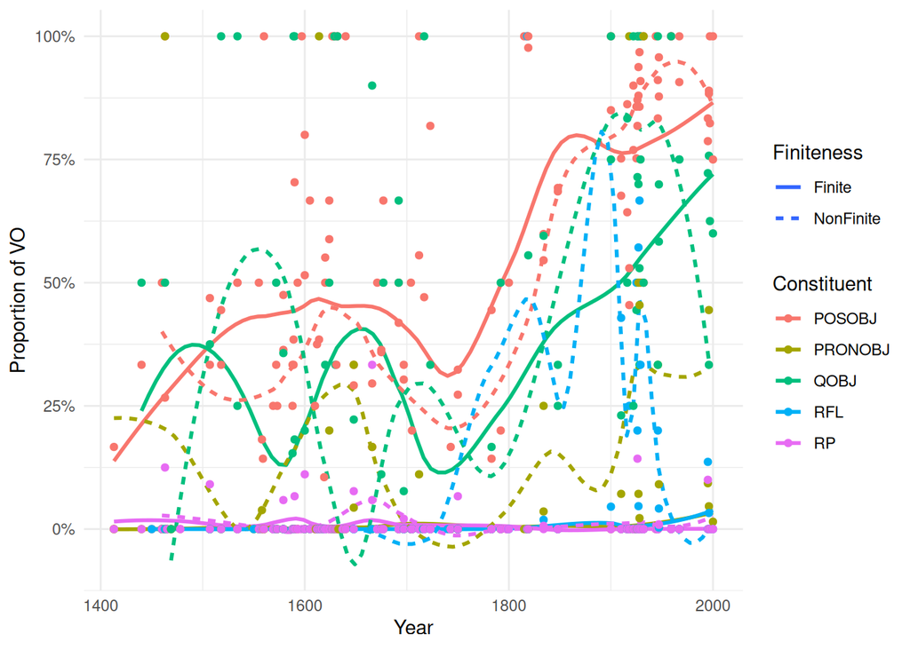

```r
data %>%
  pivot_longer(
    cols = c(RP, RFL, PRONOBJ, POSOBJ, QOBJ),
    names_to = "Constituent",
    values_to = "Order"
  ) %>%
  group_by(Year, Constituent, Finiteness) %>%
  summarise(
    n_VO = sum(Order == "VO", na.rm = TRUE),
    n_OV = sum(Order == "OV", na.rm = TRUE),
    prop_VO = n_VO / (n_VO + n_OV),
    .groups = "drop"
  ) %>%
  ggplot(aes(
    x = Year,
    y = prop_VO,
    colour = Constituent,
    linetype = Finiteness,
    group = interaction(Constituent, Finiteness)
  )) +
  geom_smooth(method = "loess", span = 0.4, se = F) +
  geom_point() +
  scale_y_continuous(labels = scales::percent_format()) +
  labs(
    x = "Year",
    y = "Proportion of VO",
    colour = "Constituent",
    linetype = "Finiteness"
  ) +
  theme_minimal()
```

#### Compare “diagnostic” ones (rfl, rp, pronobj) against regular posobj, by clause finiteness

TODO

#### Old plots below to remind what I was looking at (but redo with recoded vars)

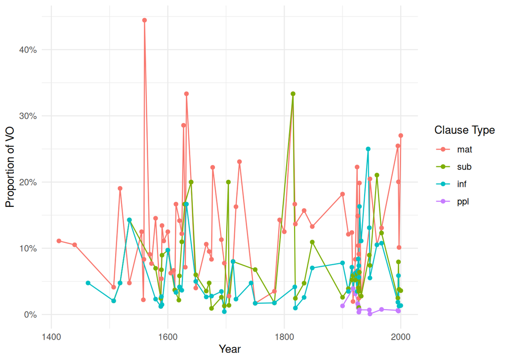

```r
year_prop <- data %>%
  group_by(WordOrder, Year, ClauseType, Corpus, Finiteness) %>%
  summarise(n = n(), .groups = "drop_last") %>%
  group_by(Year) %>%
  mutate(prop = n / sum(n))

year_prop %>%
  filter(WordOrder == "vo") %>%
  ggplot(aes(x = Year, y = prop, colour = ClauseType)) +
  geom_line() +
  geom_point() +
  scale_y_continuous(labels = scales::percent) +
  labs(
    x = "Year",
    y = "Proportion of VO",
    colour = "Clause Type"
  ) +
  theme_minimal()
```

Look at the two corpora separately as well

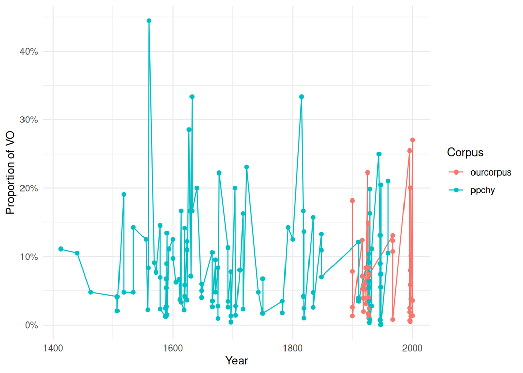

```r
year_prop %>%
  filter(WordOrder == "vo") %>%
  ggplot(aes(x = Year, y = prop, colour = Corpus)) +
  geom_line() +
  geom_point() +
  scale_y_continuous(labels = scales::percent) +
  labs(
    x = "Year",
    y = "Proportion of VO",
    colour = "Corpus"
  ) +
  theme_minimal()
```

Looking at non-finite vs finite clauses:

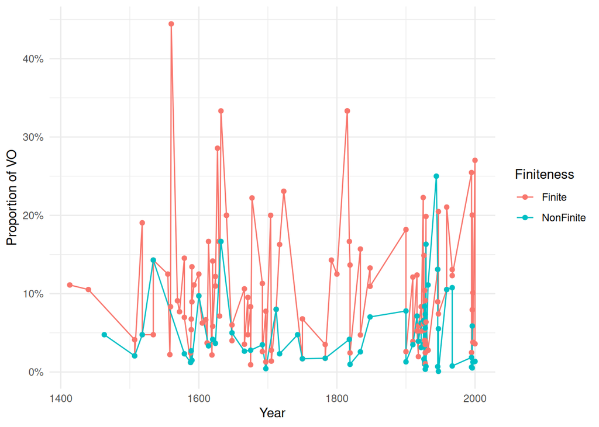

```r
year_prop %>%
  filter(WordOrder == "vo") %>%
  ggplot(aes(x = Year, y = prop, colour = Finiteness)) +
  geom_line() +
  geom_point() +
  scale_y_continuous(labels = scales::percent) +
  labs(
    x = "Year",
    y = "Proportion of VO",
    colour = "Finiteness"
  ) +
  theme_minimal()
```

## TODO

- Filter more by element type (pronouns more reliable than RP?)
- Investigate the weird peaks - specific texts